# AlimIntest analysis

Julien Tap

## Abstract

Gut microbiota richness and stability seems to be an important parameter in host-microbe symbiosis. Diet might be one way to maintain or restore high richness in the gut microbiota notably using dietary fibers. However, the impact of diet on the stability and richness of human gut microbiota is not fully characterized. In this work, through a six week nutritional trial, 19 healthy adults consumed a basal diet supplemented with 10 or 40 g dietary fiber per day for five days, followed by 15-day washout periods. Fecal samples were collected at four time points and were analyzed by a combination of 16S rRNA gene targeted pyrosequencing, intestinal cell genotoxicity and short chain fatty analysis. Metatranscriptomic sequencing approach was also done for a subgroup of subjects. Whatever the taxonomic levels studied, changing dietary fiber amount did not have the same impact for all individuals but remained significant within each individual gut microbiota at genus, family and phylum levels. Higher gut microbiota richness is associated with higher gut microbiota stability to marked changes in dietary fiber intake which is also accompanied by the modulation of the expression of numerous gut microbiota metabolic pathways like glycan and methanogenesis metabolism. Higher microbial richness is also associated with higher proportions of *Prevotella*, *Coprococcus* and *Dorea* species and higher levels of caproate and valerate. Microbiota richness was not associated with intestinal cell genotoxicity and this was not modulated by diet. This study provides new insights on the impact of gut microbiota on dietary modulation of host-microbe symbiosis.

## Study design

The aim of this study was to revaluate the diet change using different fibers intake on human health, using an integrated approach to characterize gut microbiome composition and activity. We undertook a randomized nutritional intervention in 19 healthy adults, with controlled normal diets providing 10 then 40g or 40 then 10g natural fibers per day. Four time points were collected per individual and random duplicates were added to the dataset. The microbiota composition was assessed by quantitative PCR and 454 pyrosequencing. The microbial activity was measured by metatranscriptomics. The bacterial fermentation was evaluated by short chain fatty acid analysis. In addition, the impact of the diet on host DNA damage was analysed using the standard assay, the Comet assay on HT29 cell line.

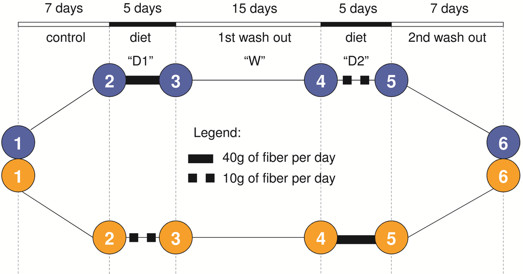

**Fig. S1.**

**Fig. S1: Cross over nutritional intervention of this study.** Each disc represents a collection point. The blue group was composed of nine individuals, who first had 40g fiber/day; the orange group of 10 individuals who started with 10g fiber/day. During the 15-day washout period, the individuals were on their usual personal diet without any constraint.

## Read and Preprocessing data

### Replicates sequencing analysis

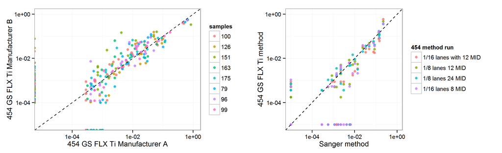

Technical replicates comparisons based on genera relative log10 proportion

**Fig. S4: Technical replicates comparisons based on dominant genera relative log10 proportion.** (Left panel) Eight replicates pyrosequenced by two different companies were compared and show high significant correlation based on genera distribution (rho=0.8, p<0.05, spearman method). (Right panel) A sample sequenced by both Sanger and pyrosequencing methods with different lane and MID configurations shows the same trend.

### Whole 454 reads dataset processing

Sequences reads data were processed with *Lotus* with at least 200 nucleotides as quality filter to build OTU and 100 pb to remap reads against OTU representatives sequences. More information about *Lotus* documentation could be found here : http://psbweb05.psb.ugent.be/lotus/documentation.html

In order to have a overview, here is some samples of metadata used which include study design parameters like “Diet run” with also SCFA and quantitative PCR assays.

**study design**

| Sample_ID | Sample_ID2 | Time.point | Subject_Id | Diet_run | Seq_filtered |
| --- | --- | --- | --- | --- | --- |
| 3 | 19J0 | 2 | 19 | r40-10 | 2501 |
| 6 | 15J0 | 2 | 15 | r10-40 | 11348 |
| 8 | 17J21 | 4 | 17 | r10-40 | 1068 |
| 9 | 12J25 | 5 | 12 | r40-10 | 1751 |
| 11 | 1J0 | 2 | 1 | r10-40 | 8032 |
| 12 | 13J22 | 4 | 13 | r40-10 | 8345 |

**SCFA assays**

| acetate | propionate | isobutyrate | butyrate | isovalerate | valerate | isocaproate | caproate |
| --- | --- | --- | --- | --- | --- | --- | --- |
| 33.40 | 14.21 | 1.25 | 19.84 | 1.51 | 1.52 | 0.03 | 0.05 |
| 9.40 | 4.02 | 0.61 | 2.77 | 0.74 | 0.55 | 0.08 | 0.17 |
| 54.75 | 11.24 | 0.32 | 38.23 | 0.43 | 0.91 | 0.06 | 1.81 |
| 26.11 | 13.94 | 1.52 | 13.42 | 2.34 | 2.52 | 0.00 | 0.97 |
| 12.69 | 4.69 | 0.65 | 5.50 | 0.75 | 0.88 | 0.01 | 0.57 |
| 33.37 | 11.45 | 2.00 | 31.19 | 2.77 | 1.88 | 0.10 | 0.10 |

**qPCR and comet assays**

| log_all_bacteria_ADN | log_Cleptum_ADN | log_Bcoccoides_ADN | log_Bacteroides_Prevotella_ADN | log_Bifidobacteria_ADN | log_Ecoli_ADN | log_Lactobacillus_ADN | pH.eaux.fécales | Comet_assay |
| --- | --- | --- | --- | --- | --- | --- | --- | --- |
| 11.32 | 11.60 | 10.48 | 10.81 | 9.76 | 8.31 | 6.00 | 5.77 | 31.45 |
| 11.39 | 10.81 | 11.41 | 10.07 | 10.61 | 8.83 | 8.45 | NA | NA |
| 11.73 | 11.33 | 10.51 | 10.74 | 9.80 | 8.33 | 7.07 | 5.16 | 69.12 |
| 11.69 | 11.95 | 10.70 | 10.61 | 9.74 | 7.81 | 7.50 | 6.80 | 53.71 |
| 11.54 | 11.54 | 10.73 | 10.72 | 6.87 | 9.21 | 7.33 | 6.20 | 47.23 |
| 10.85 | 11.08 | 10.03 | 10.12 | 9.47 | 8.53 | 6.00 | NA | NA |

## Numerical Ecology

Here we calculated the microbial richness (alpha-diversity) at the same sequencing depth for each sample (n = 1000 reads). Rarefaction curves analysis was also be done for each sample.

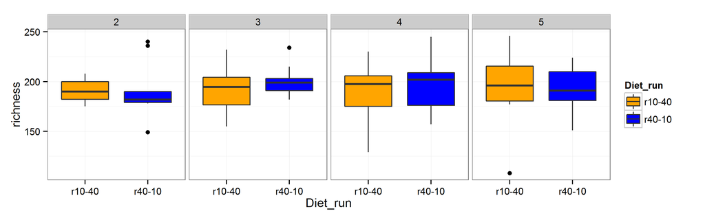

**Fig. S2 (top panel). Gut microbiota richness and composition assessed by 454 and qPCR as function of diet over time**. 454 pyrosequencing was used to assess the microbial richness and qPCR was used to quantify major microbial group overtime including the basal time. The major microbial group quantification was normalized using the all bacteria qPCR assay.

There is no significant changes of gut microbial richness overtime.

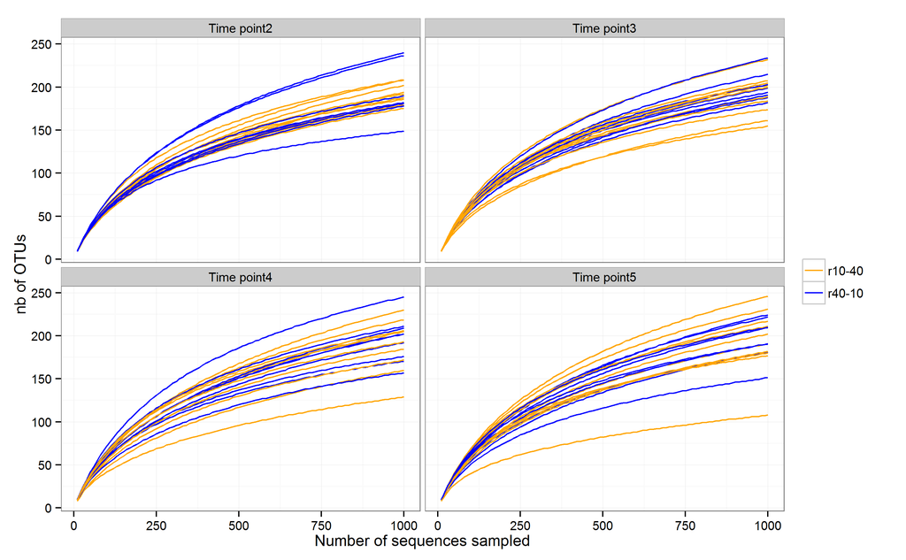

Rarefaction analysis

**Fig. S5: Rarefaction analysis of the pyrosequencing data by diet time point.** Number of unique OTUs identified in the 76 samples relative to the sequencing depth. For time points and nutritional study scheme see Fig. S1.

## Quantification of individuality and diet factor

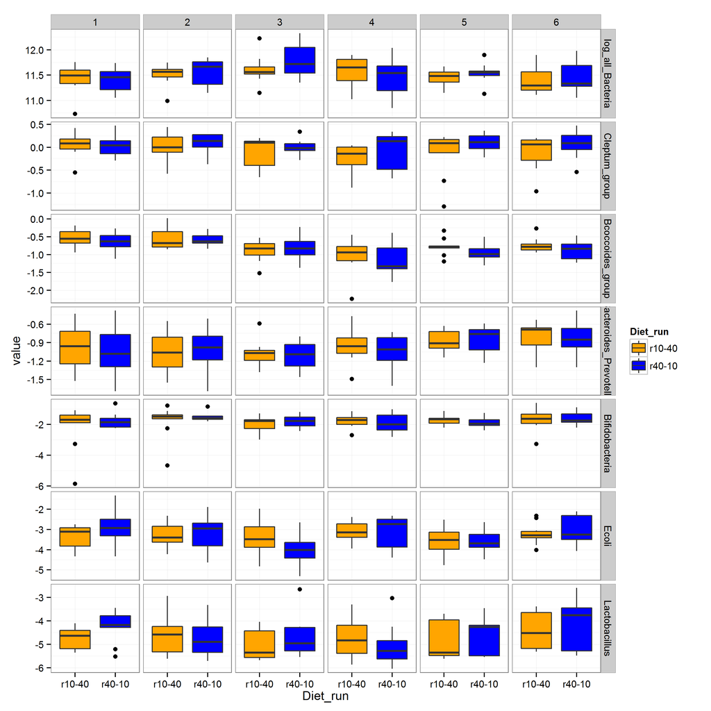

**Fig. S2 (bottom panel). Gut microbiota richness and composition assessed by 454 and qPCR as function of diet over time.**

A between class analysis is done to quantify individual and diet effect on global variation. Microbiota summaries were done after normalisation at phylum, class, order, family, genus and OTU levels using 454 pyrosequencing sequencing. Inertia attributed to diet and host was then challenged against Monte Carlo simulated dataset.

```r
otu_norm = prop.table(as.matrix(alimintestData$otu),2)

microbiota_tax = list(
    phylum_tax = apply(otu_norm, 2, tapply, alimintestData$tax$phylum, sum ),
    class_tax  = apply(otu_norm, 2, tapply, alimintestData$tax$class, sum ),
    order_tax  = apply(otu_norm, 2, tapply, alimintestData$tax$order, sum ),
    family_tax = apply(otu_norm, 2, tapply, alimintestData$tax$family, sum ),
    genus_tax  = apply(otu_norm, 2, tapply, alimintestData$tax$genus, sum ),
    otu_norm   = noise.removal(otu_norm, percent=1)
)

metadata76            = alimintestData$metadata
metadata76$Time.point = as.factor(metadata76$Time.point)

microbiota_tax_variations=alimintest_metadata_pca=sapply(microbiota_tax, function(x) {

x                  = as.data.frame(t(log10(x + 10^-5)))
x.pca              = dudi.pca(x,    scannf=FALSE, nf=2)
x.bca.ind          = bca(x.pca,     scannf=FALSE, nf=2, fac=as.factor(metadata76$Subject_Id))
x.wca.ind          = bca(x.pca,     scannf=FALSE, nf=2, fac=as.factor(metadata76$Subject_Id))
x.bca.diet         = bca(x.pca,     scannf=FALSE, nf=2, fac=as.factor(metadata76$Diet_run:metadata76$Time.point))
#x.wca.ind.bca.diet = bca(x.wca.ind, scannf=FALSE, nf=2, fac=as.factor(metadata76$Diet_run:metadata76$Time.point))
x.wca.ind.bca.diet = bca(wca(dudi.pca(x, scannf=F, nf=2), scannf=F, nf=2, fac=as.factor(metadata76$Subject_Id)), scannf=F, nf=2, fac=as.factor(metadata76$Diet_run:metadata76$Time.point) )

x.bca.ind.res          = randtest(x.bca.ind)
x.bca.diet.res         = randtest(x.bca.diet)
x.wca.ind.bca.diet.res = randtest(x.wca.ind.bca.diet)

res = data.frame(ind.obs        = x.bca.ind.res$obs*100,
                 ind.sim        = quantile(x.bca.ind.res$sim, 0.95)[[1]]*100,
                 diet.obs       = x.bca.diet.res$obs*100,
                 diet.sim       = quantile(x.bca.diet.res$sim,0.95)[[1]]*100,
                 diet.w.ind.obs = x.wca.ind.bca.diet.res$obs*100,
                 diet.w.ind.sim = quantile(x.wca.ind.bca.diet.res$sim, 0.95)[[1]]*100
                 )
return(res)
}
)
```

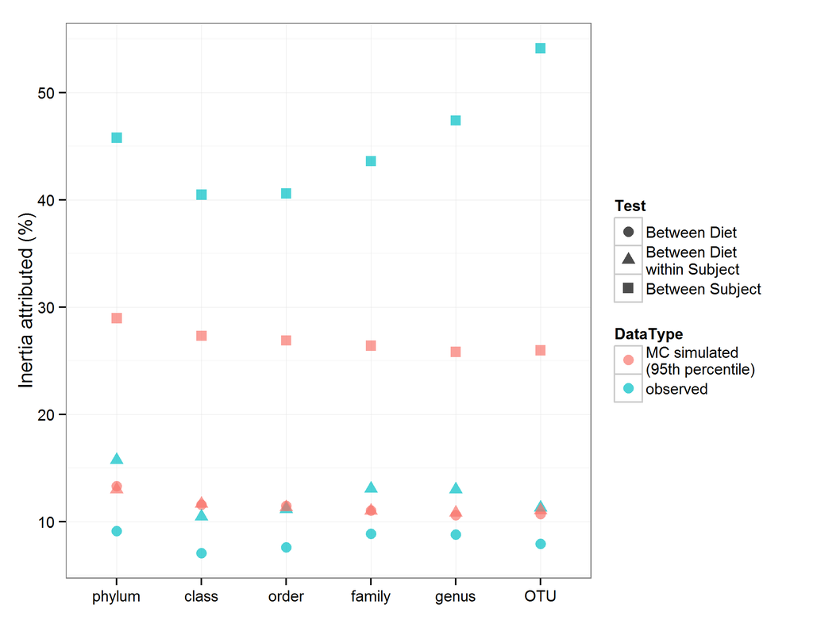

Between class analysis using diet and individual as factors

**Fig. 1: Gut microbiota inertia variations according to diet and subjects at different taxonomic levels.** Between class analysis was used to measure the inertia using diet and individual alternatively as instrumental variable. Monte Carlo (MC) simulated inertia (n=1000 simulation) was used to assess the significance of inertia attributed to different factors. When observed inertia is higher to the 95th percentile of MC simulated inertia then it is considered as significant.

When the observed inertia is above the 95th percentile of Monte Carlo (MC) simulated inertia, the effect was considered as significant.

## Richness and comet vs Microbial changes

We tested if microbial changes over-time is associated with microbial richness and genotoxicity (comet assays). We stratified observations into groups corresponding to samples taking after 10g fiber diet, 40g fiber diet and usual diet (corresponding to the washout period). Microbial changes was evaluated using the JSD distance metrics.

```
##
##  Spearman's rank correlation rho
##
## data:  log10(microbial.change$jsd) and microbial.change$richness.before
## S = 41473.68, p-value = 0.008769
## alternative hypothesis: true rho is not equal to 0
## sample estimates:
##        rho
## -0.3441042
```

```
##
##  Spearman's rank correlation rho
##
## data:  log10(microbial.change$jsd) and microbial.change$comet.after
## S = 15328, p-value = 0.1224
## alternative hypothesis: true rho is not equal to 0
## sample estimates:
##        rho
## -0.2420387
```

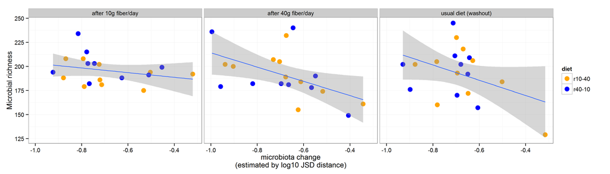

**Microbiota variations measured by JSD metrics is not associated with diet change**

```
##
##  Pairwise comparisons using Wilcoxon signed rank test
##
## data:  data.frame(microbial.change, group)$jsd and group
##
##                      after 10g fiber/day after 40g fiber/day
## after 40g fiber/day  0.95                -
## usual diet (washout) 0.98                0.65
##
## P value adjustment method: none
```

```
##
##  Pairwise comparisons using Wilcoxon signed rank test
##
## data:  data.frame(microbial.change, group)$jsd and data.frame(microbial.change, group)$change
##
##     2_3  3_4
## 3_4 0.54 -
## 4_5 0.89 0.98
##
## P value adjustment method: none
```

**Associations between Microbial change and richness before diet and comet assays after diet**. Associations were assessed by Spearman rho correlation and p.value were indicated in parenthesis.

|  | Richness before diet | comet assays after diet |
| --- | --- | --- |
| 10g | -0.34 (0.158) | -0.31 (0.273) |
| 40g | -0.55 (0.014) | -0.34 (0.24) |
| usual | -0.27 (0.262) | 0.12 (0.693) |

## Gut microbiota richness and SCFA

**Spearman rho correlation between microbiota richness, bacterial genera proportions and SCFAs**

```
##         acetate propionate isobutyrate   butyrate isovalerate valerate
## [1,] -0.2183012 -0.1890843   0.3102015 -0.2706303   0.2631213  0.13788
##      isocaproate  caproate
## [1,]  -0.1115975 0.2775444
```

```
##      Acetanaerobacterium Acidaminococcus Actinomyces Alistipes Anaerofilum
## [1,]           0.1545874       0.1805459 -0.09310326 0.3882788   0.2239111
##      Anaerofustis Anaerostipes Anaerotruncus Bacteroides Barnesiella
## [1,]   0.01511437    0.1049792    0.07742451  -0.3777611     0.01065
##      Bifidobacterium Bilophila    Blautia Butyricicoccus Butyricimonas
## [1,]      -0.2196145 0.0977351 -0.0611229     -0.1057037     0.1337533
##      Cloacibacterium Clostridium IV Clostridium sensu stricto
## [1,]      -0.1764155      0.5188266                 0.1264299
##      Clostridium XI Clostridium XlVa Clostridium XlVb Clostridium XVIII
## [1,]    0.005470834       0.05587089         0.024553     -0.0005084208
##      Collinsella Coprococcus Desulfovibrio   Dialister     Dorea
## [1,]   0.3221403   0.3764618     0.3959048 -0.03537537 0.3017712
##      Eggerthella Enterococcus Enterorhabdus
## [1,]  -0.2123056    0.1270853     0.1672555
##      Erysipelotrichaceae_incertae_sedis Escherichia/Shigella Eubacterium
## [1,]                          0.2818417          -0.06043091  -0.1069168
##      Faecalibacterium Flavonifractor Fusobacterium     Gemella   Gemmiger
## [1,]      -0.03162142    -0.01299412     0.1742295 -0.06895094 0.06087671
##      Gordonibacter Granulicatella Haemophilus Helicobacter  Holdemania
## [1,]  -0.003198102    -0.04019388 -0.02910523   -0.1478236 -0.08126789
##      Howardella Klebsiella Lachnospiracea_incertae_sedis Lactobacillus
## [1,] -0.1035626 -0.1852794                     0.2706011    -0.2019344
##      Lactococcus Lactonifactor  Megamonas Megasphaera Mitsuokella
## [1,]   0.2102673    0.04804036 -0.2936626  -0.2595302   0.3762132
##      Mogibacterium  Odoribacter Olsenella Oscillibacter Parabacteroides
## [1,]      0.093017 -0.008643248 0.1234096     0.2696301      0.02941941
##      Paraprevotella Parasutterella Pedobacter Peptococcus
## [1,]      0.3345471    -0.01969422 -0.1922139   0.1801182
##      Peptostreptococcus Phascolarctobacterium Porphyromonas Prevotella
## [1,]        -0.01890425            0.09364323     0.2628525  0.4243925
##       Roseburia     Rothia Ruminococcus   Slackia Sphingomonas Sporobacter
## [1,] -0.1028107 -0.1493881   0.02574028 0.3491624    -0.111744 0.008292369
##      Streptococcus Succiniclasticum Sutterella Turicibacter Undibacterium
## [1,]    -0.1230696        0.1782049 -0.1594161  -0.01328511   -0.01877695
##      Veillonella
## [1,]  -0.1170949
```

SCFA and microbiota composition at genus levels shared a co-structured inertia (RV = 15.92 %, p = 0.009) supported by a significant Monte Carlo test.

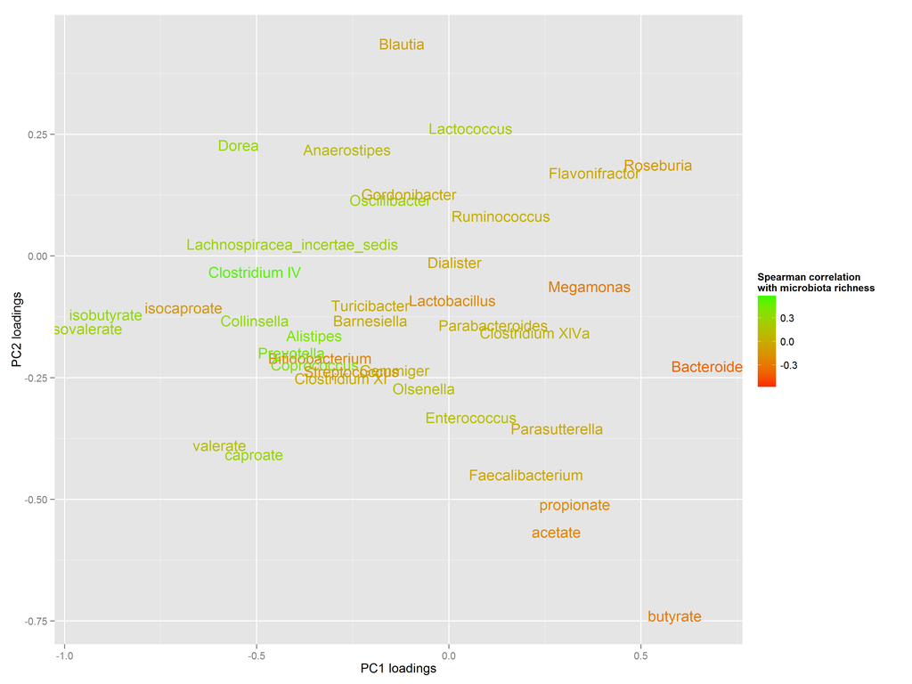

global association between OTU richness, SCFA and bacterial genera using co-inertia analysis

**Fig. S7: Global association between microbial OTU richness, SCFA and bacterial genera using co-inertia analysis.** The two first principal component loading from the co-inertia analysis between SCFA and microbial genera are plotted. Color gradient account for spearman correlation strengh between SCFA and bacterial genera with microbial OTU richness.

From the co-inertia analysis, we observed that i) SCFAs profile are significantly associated with bacteria genera proportions ii) and this associations is correlated with bacterial richness. For example, caproate, valerate, *Prevotella*, *Coprococcus* are positively associated with richness while butyrate, propionate, acetate and *Bacteroides* are negatively associated with richness. We choose those observations to build the main figure below. The first component of the co-inertia analysis (PC1) represent well those associations.

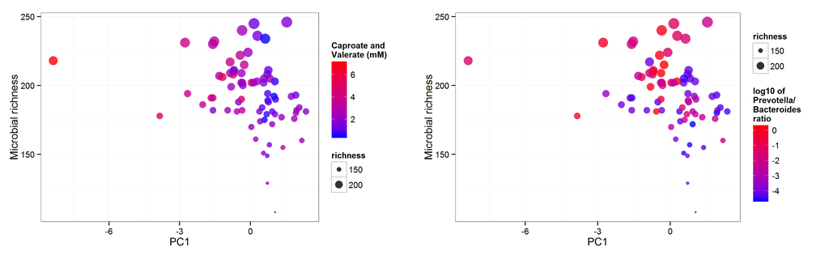

**Fig. 3: Association between microbial OTU richness, SCFA and bacterial genera.** The first principal component (PC1) from the co-inertia analysis between SCFA and microbial genera was associated significantly with microbial richness. Circle size account for OTU richness and color gradient account for caproate and valerate amount (left panel) and *Prevotella*/*Bacteroides* ratio (right panel)

## Conclusions

This study provided the following information:

- The response to the diet change was fast but specific to individual.
- This specific response is dependent of gut species richness. Low species richness microbiota showed more impact when diet change notably with high amount of fiber while high rich microbiota showed more stability *whatever the diet*.
- High rich microbiota have a high amount of caproate and valerate associated with *Prevotella*, *Coprococcus* and *Dorea* genera.
- Transcriptomics showed an increase in methanogenesis and glycan metabolism at 40g/fiber.
- The genotoxicity on HT29 cells did not correlate with diet, gut gene richness and SCFA profile.

We conclude that gut bacterial richness have to be taken in account for future nutritional intervention.